# week05_in_class

## Week 5

### Notes on project 1

- result comment: 'this plot shows a very interesting behavior. Let's move to the next result' **this comment is not complete**
- Equation for the sequence was missing.
- comments and text descriptions are two different things, and both are necessary to a project
- `list`, `len`,... should not be used as variable names
- careful to terminology/typos
- `return` does not need parenthesis -> `return a`
- If your grade is below C, you should send me an email
- **Who is the report for?** formal text/terminology, level of information should be enough for your 'roommate' to understand the project.

```python
list(range(5))
```

```
[0, 1, 2, 3, 4]
```

### quick note on sample quiz 5

Write the code to generate the list of the halves of the first 100 integers. Use list comprehension

```python
mylist=[k/2 for k in range(101) ]
print(mylist)
```

```
[0.0, 0.5, 1.0, 1.5, 2.0, 2.5, 3.0, 3.5, 4.0, 4.5, 5.0, 5.5, 6.0, 6.5, 7.0, 7.5, 8.0, 8.5, 9.0, 9.5, 10.0, 10.5, 11.0, 11.5, 12.0, 12.5, 13.0, 13.5, 14.0, 14.5, 15.0, 15.5, 16.0, 16.5, 17.0, 17.5, 18.0, 18.5, 19.0, 19.5, 20.0, 20.5, 21.0, 21.5, 22.0, 22.5, 23.0, 23.5, 24.0, 24.5, 25.0, 25.5, 26.0, 2…
```

Suppose the list `plist` contains the first 500 prime numbers. Using list comprehension produce the list `loglist` of the logarithm of the numbers in `plist`

```python
from math import log
plist=range(1,6)
mylist2=[log(k) for k in plist]
print(mylist2)
```

```
[0.0, 0.6931471805599453, 1.0986122886681098, 1.3862943611198906, 1.6094379124341003]
```

Suppose the list `plist` contains the first 500 prime numbers. Using list comprehension produce the list `mylist` of the numbers in `plist` smaller than 300 that are odd

```python
plist=range(1,6)

mylist=[k for k in plist if ((k<300) and (k%2==1))]
print(mylist)
```

```
[1, 3, 5]
```

```python
x=[k/99 +1 for k in range(100)]
print(x)
```

```
[1.0, 1.0101010101010102, 1.02020202020202, 1.0303030303030303, 1.0404040404040404, 1.0505050505050506, 1.0606060606060606, 1.0707070707070707, 1.0808080808080809, 1.0909090909090908, 1.101010101010101, 1.1111111111111112, 1.121212121212121, 1.1313131313131313, 1.1414141414141414, 1.1515151515151516…
```

`myprimes(n)`: idea loop on all numbers $\leq n$ if `isprime()` we append it.

`primedec(n)`:

- we start with `n` and want all prime divisors (with repetition)
- we get all primes $\leq n$
- for each prime k:
  - as long as k divides n, we append k, and update n to n/k
    - if not: move to next prime (do nothing) we do this as long as `n!=1`

```python
def snail(n):
    # the function returns the x and y coordinates
    # necessary to build the snail pattern
    mov = 'right' # movement direction
    counter = 1 # how many times we should move in the current direction
    times_m = 0 # how many times have we moved in a specific direction


    x,y=0,0
    xlist=[x]
    ylist=[y]

    for k in range(n):
        if mov == 'right':
            x+=1
            times_m+=1
            if times_m == counter:
                mov='up'
                times_m=0
        elif mov == 'up':
            y+=1
            times_m+=1
            if times_m == counter:
                mov='left' # update direction
                times_m=0 # update of times moved in new/current direction
                counter+=1 # update of max movement
        elif mov == 'left':
            x-=1
            times_m+=1
            if times_m == counter:
                mov='down'
                times_m=0
        elif mov == 'down':
            y-=1
            times_m+=1
            if times_m == counter:
                mov='right' # update direction
                times_m=0 # update of times moved in new/current direction
                counter+=1 # update of max movement
        xlist.append(x)
        ylist.append(y)

    return xlist,ylist
```

```python
x,y=snail(4)
print('x: ',x)
print('y: ',y)
```

```
x:  [0, 1, 1, 0, -1]
y:  [0, 0, 1, 1, 1]
```

```python
import matplotlib.pyplot as plt
```

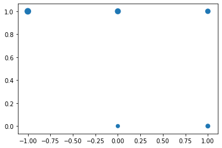

```python
plt.scatter(x,y,linewidths=[1,2,3,4,5]);
```

```
x:  [0, 1, 1, 0, -1, -1, -1, 0, 1, 2, 2, 2, 2, 1]
y:  [0, 0, 1, 1, 1, 0, -1, -1, -1, -1, 0, 1, 2, 2]
```

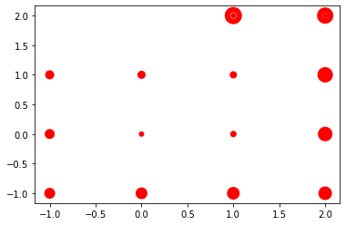

```python
x,y=snail(13)
print('x: ',x)
print('y: ',y)
plt.scatter(x,y,c='r',linewidths=range(14));
```

## Note on subplots

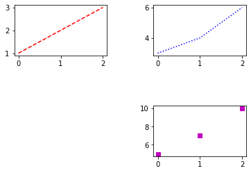

```python
plt.subplots_adjust(wspace=0.5,hspace=1)
plt.subplot(2,2,1)
plt.plot([1,2,3],'r--')
plt.subplot(2,2,2)
plt.plot([3,4,6],'b:')
plt.subplot(2,2,4)
plt.plot([5,7,10],'ms')
```